# 6) EEG Data Reduction and Exploration

# Calculating Absolute Power (Data Reduction)

So in plots below, we also take the log of the outcome and then conver these values into z-scores. From the plots we see that in the log scale values are no longer that extreme, aka not that far away from the mean, which means that our analysis will probably work on our outcome (absolute power) in this scale.

We previously dropped the transformed scales (they are **non-linear**) since they will be different when recalculated from the remaining frequencies/averages. Basically, the math needs to be done in the raw scale first and then transformed, we can’t do the math in the transformed scale (e.g., averaging or summing values).

All Power Features Averaged Across Channels Within Region and Hemisphere levels

| ID | frequency | region_hemisphere | Sex | Age | Spell_group | FB | power | rel_power | n_channels |
| --- | --- | --- | --- | --- | --- | --- | --- | --- | --- |
| 10053 | 0.50 | left_central | F | 19 | high | delta | 1.2902148 | 0.0941845 | 6 |
| 10053 | 0.50 | left_frontal | F | 19 | high | delta | 2.4398572 | 0.1088411 | 10 |
| 10053 | 0.50 | left_occipital | F | 19 | high | delta | 2.7795316 | 0.0276822 | 3 |
| 10053 | 0.50 | left_parietal | F | 19 | high | delta | 1.5389951 | 0.0574800 | 4 |
| 10053 | 0.50 | left_temporal | F | 19 | high | delta | 3.9261068 | 0.1856465 | 4 |
| 10053 | 0.50 | right_central | F | 19 | high | delta | 1.1390017 | 0.0762513 | 6 |
| 10053 | 0.50 | right_frontal | F | 19 | high | delta | 3.3002836 | 0.1261224 | 10 |
| 10053 | 0.50 | right_occipital | F | 19 | high | delta | 2.5531300 | 0.0351236 | 3 |
| 10053 | 0.50 | right_parietal | F | 19 | high | delta | 1.8524014 | 0.0554005 | 4 |
| 10053 | 0.50 | right_temporal | F | 19 | high | delta | 2.0466799 | 0.1122828 | 4 |
| 10053 | 0.75 | left_central | F | 19 | high | delta | 0.4800220 | 0.0353943 | 6 |
| 10053 | 0.75 | left_frontal | F | 19 | high | delta | 0.9835669 | 0.0473693 | 10 |
| 10053 | 0.75 | left_occipital | F | 19 | high | delta | 1.9042136 | 0.0189788 | 3 |
| 10053 | 0.75 | left_parietal | F | 19 | high | delta | 0.8041549 | 0.0280317 | 4 |
| 10053 | 0.75 | left_temporal | F | 19 | high | delta | 1.2577952 | 0.0589885 | 4 |
| 10053 | 0.75 | right_central | F | 19 | high | delta | 0.4965972 | 0.0331360 | 6 |
| 10053 | 0.75 | right_frontal | F | 19 | high | delta | 1.3997080 | 0.0556704 | 10 |
| 10053 | 0.75 | right_occipital | F | 19 | high | delta | 1.7460942 | 0.0240061 | 3 |
| 10053 | 0.75 | right_parietal | F | 19 | high | delta | 0.9389522 | 0.0275734 | 4 |
| 10053 | 0.75 | right_temporal | F | 19 | high | delta | 0.7568157 | 0.0423226 | 4 |

Datapoints per person based on region, its hemisphere, and frequency bands

|  | delta | theta | alpha1 | alpha2 | Sum |
| --- | --- | --- | --- | --- | --- |
| left_central | 1 | 1 | 1 | 1 | 4 |
| left_frontal | 1 | 1 | 1 | 1 | 4 |
| left_occipital | 1 | 1 | 1 | 1 | 4 |
| left_parietal | 1 | 1 | 1 | 1 | 4 |
| left_temporal | 1 | 1 | 1 | 1 | 4 |
| right_central | 1 | 1 | 1 | 1 | 4 |
| right_frontal | 1 | 1 | 1 | 1 | 4 |
| right_occipital | 1 | 1 | 1 | 1 | 4 |
| right_parietal | 1 | 1 | 1 | 1 | 4 |
| right_temporal | 1 | 1 | 1 | 1 | 4 |
| Sum | 10 | 10 | 10 | 10 | 40 |

This is the table that will be used for the final analysis.

Final dataset ready for analysis

| ID | region_hemisphere | FB | Sex | Age | Spell_group | absolute_power | relative_power | log_absolute_power | logit_relative_power | region | hemisphere |
| --- | --- | --- | --- | --- | --- | --- | --- | --- | --- | --- | --- |
| 10053 | left_central | delta | F | 19 | high | 0.9338499 | 0.0691686 | -0.0684396 | -2.599531 | central | left |
| 10053 | left_central | theta | F | 19 | high | 0.2772296 | 0.0210020 | -1.2829093 | -3.841914 | central | left |
| 10053 | left_central | alpha1 | F | 19 | high | 0.5951903 | 0.0441619 | -0.5188740 | -3.074726 | central | left |
| 10053 | left_central | alpha2 | F | 19 | high | 0.9233089 | 0.0699222 | -0.0797915 | -2.587885 | central | left |
| 10053 | left_frontal | delta | F | 19 | high | 1.8135412 | 0.0865646 | 0.5952814 | -2.356321 | frontal | left |
| 10053 | left_frontal | theta | F | 19 | high | 0.3058836 | 0.0162926 | -1.1845505 | -4.100615 | frontal | left |
| 10053 | left_frontal | alpha1 | F | 19 | high | 0.5766021 | 0.0354402 | -0.5506028 | -3.303826 | frontal | left |
| 10053 | left_frontal | alpha2 | F | 19 | high | 1.1471163 | 0.0746631 | 0.1372512 | -2.517171 | frontal | left |
| 10053 | left_occipital | delta | F | 19 | high | 2.8423654 | 0.0283104 | 1.0446366 | -3.535808 | occipital | left |
| 10053 | left_occipital | theta | F | 19 | high | 0.6310969 | 0.0062773 | -0.4602958 | -5.064511 | occipital | left |
| 10053 | left_occipital | alpha1 | F | 19 | high | 2.4102357 | 0.0240628 | 0.8797246 | -3.702732 | occipital | left |
| 10053 | left_occipital | alpha2 | F | 19 | high | 15.7408556 | 0.1569991 | 2.7562596 | -1.680728 | occipital | left |
| 10053 | left_parietal | delta | F | 19 | high | 1.3469941 | 0.0468137 | 0.2978755 | -3.013634 | parietal | left |
| 10053 | left_parietal | theta | F | 19 | high | 0.3314796 | 0.0107439 | -1.1041890 | -4.522615 | parietal | left |
| 10053 | left_parietal | alpha1 | F | 19 | high | 1.0723847 | 0.0368348 | 0.0698849 | -3.263782 | parietal | left |
| 10053 | left_parietal | alpha2 | F | 19 | high | 3.4238317 | 0.1166203 | 1.2307603 | -2.024831 | parietal | left |
| 10053 | left_temporal | delta | F | 19 | high | 2.3306735 | 0.1088440 | 0.8461573 | -2.102604 | temporal | left |
| 10053 | left_temporal | theta | F | 19 | high | 0.3926362 | 0.0191312 | -0.9348717 | -3.937120 | temporal | left |
| 10053 | left_temporal | alpha1 | F | 19 | high | 0.5366570 | 0.0263792 | -0.6223962 | -3.608446 | temporal | left |
| 10053 | left_temporal | alpha2 | F | 19 | high | 1.0769872 | 0.0517468 | 0.0741675 | -2.908258 | temporal | left |

```r
# Change the working directory
setwd(clean_data_output)

# Save the ARFA data with the IRT scores
saveRDS(final_dat, "6_final.rds")
```

# Visualizing the Data As Power Representing Frequency Bands and Topographical Regions (Z - transformed)

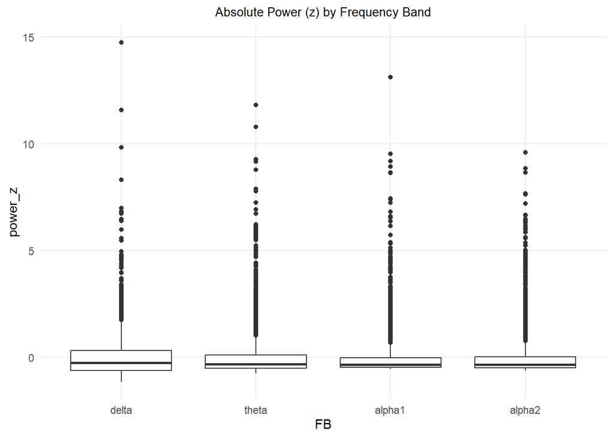

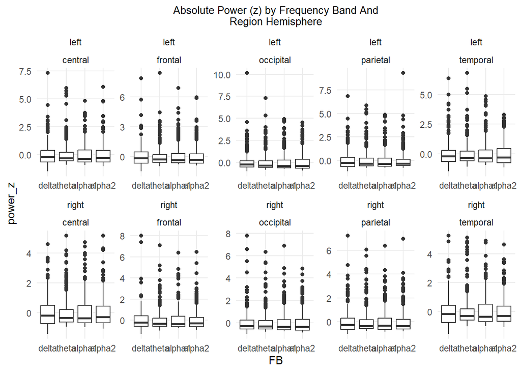

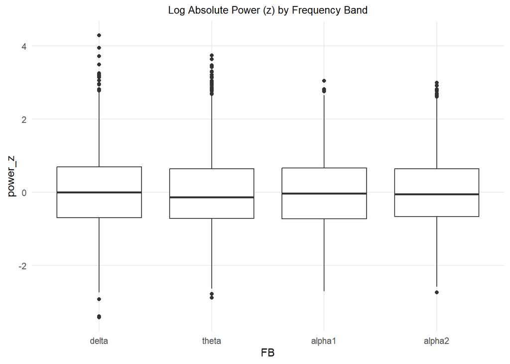

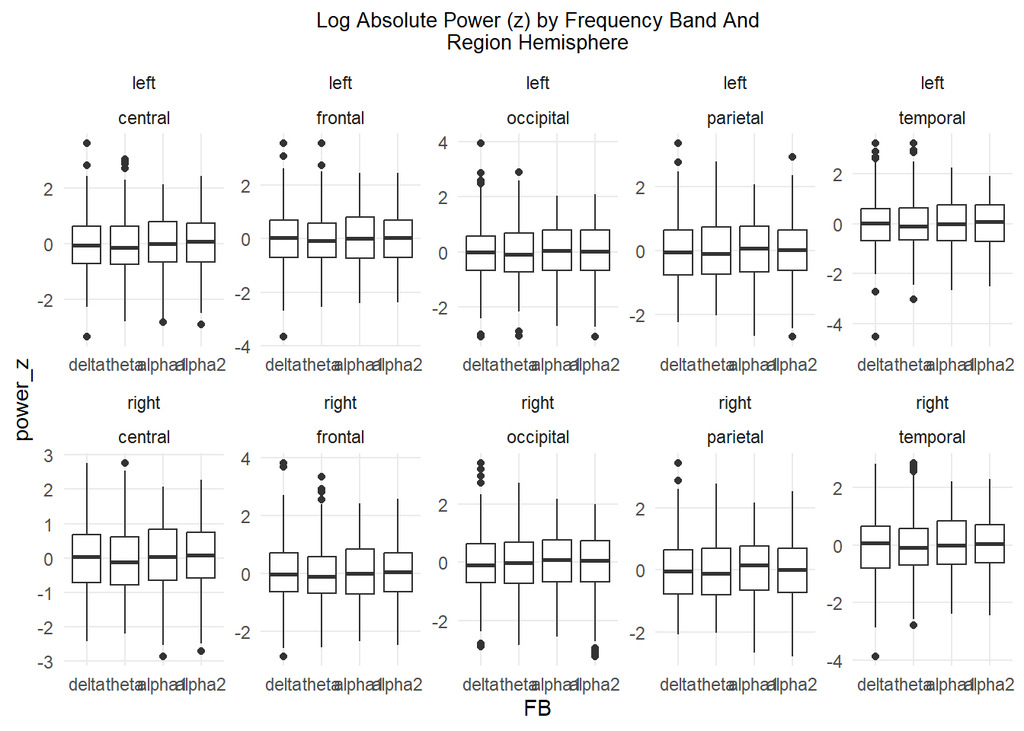

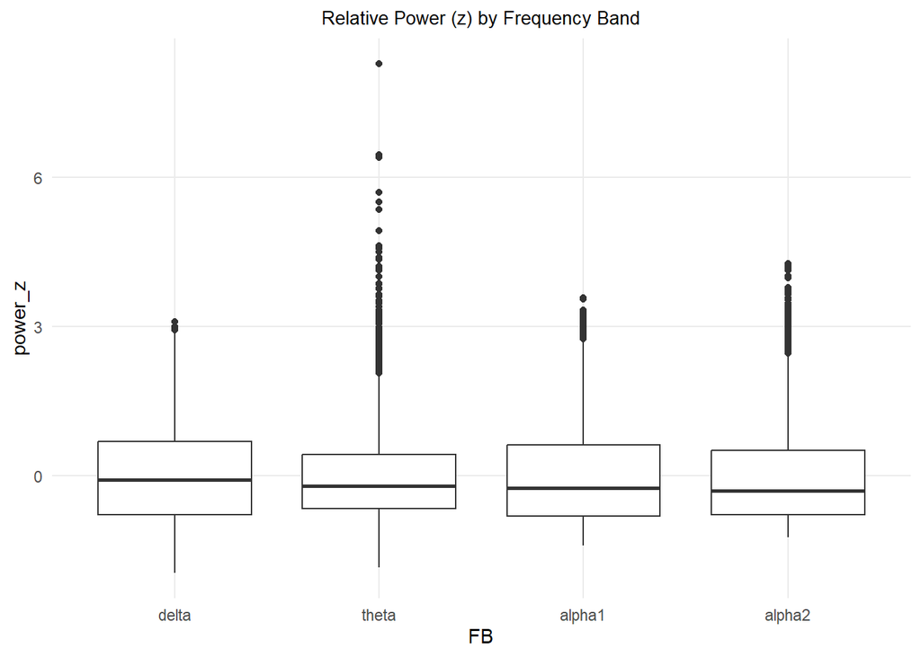

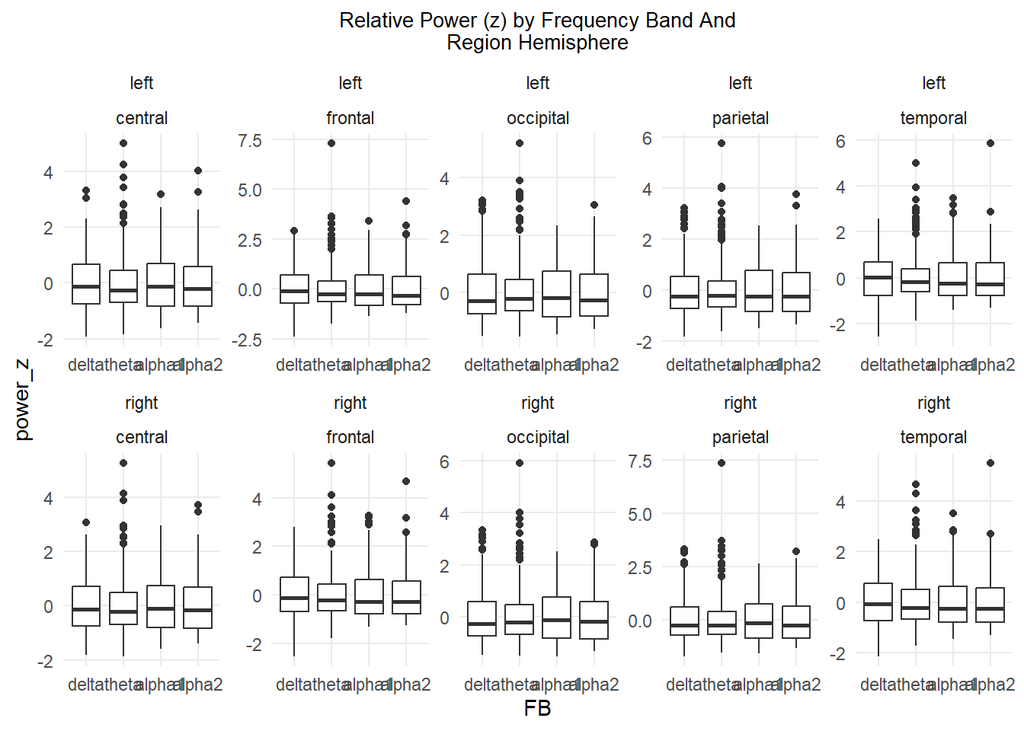

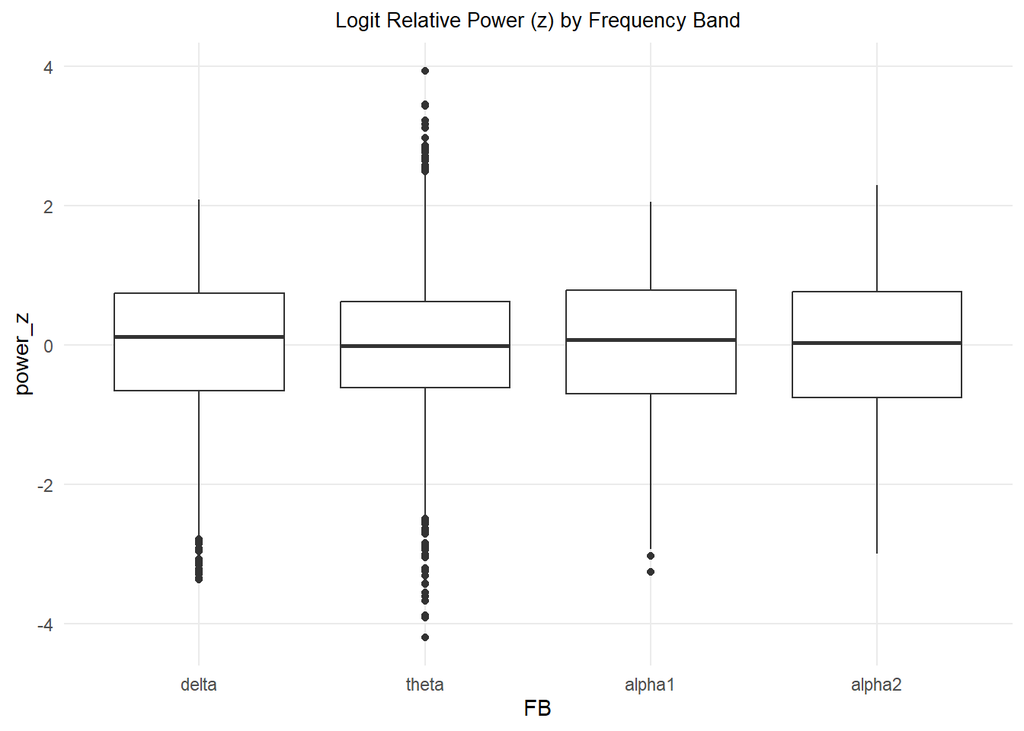

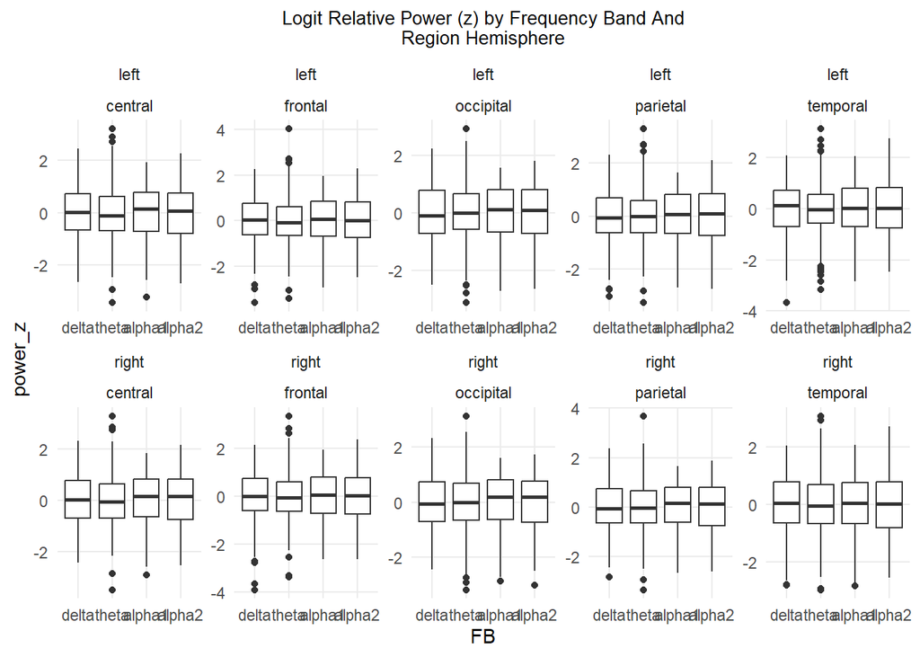

# Visualizing Potential Group Differences in The Log and Logit Scale for Spelling

There seem to be no group differences in either the log or logit scale

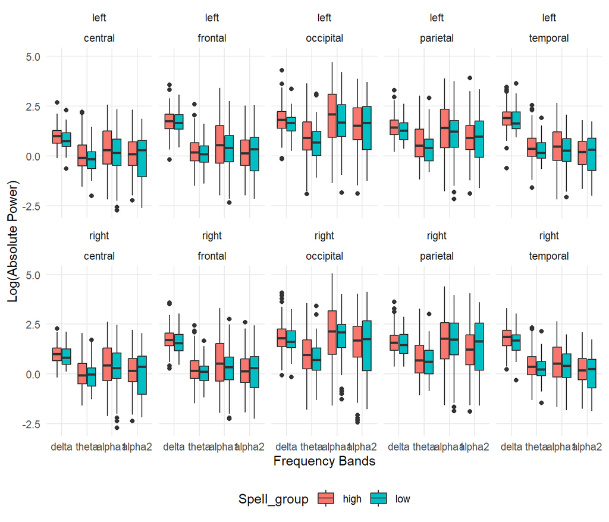

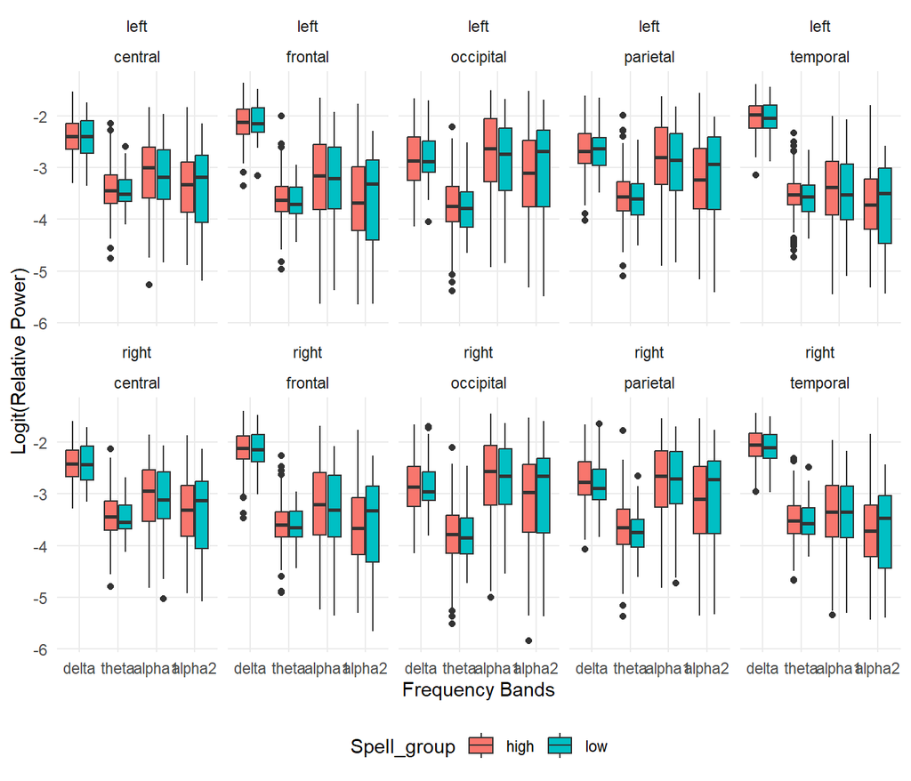

# Visualizing the Relationship Between Log and Logit Scale Power and Age

- We can see that with age log absolute power decreases as we would expect.

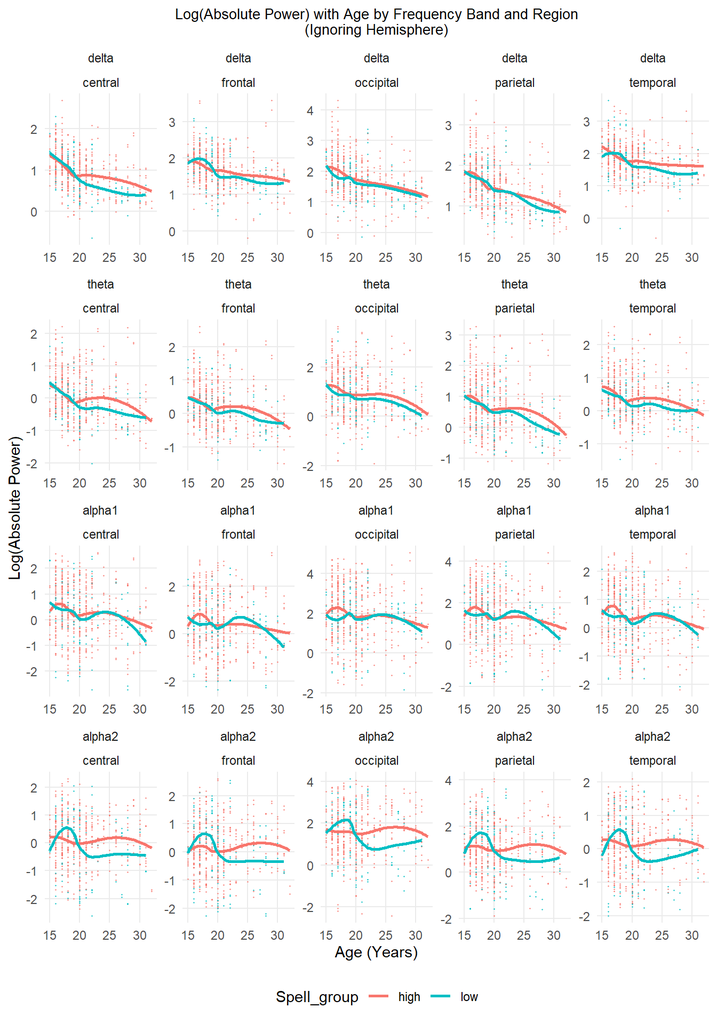

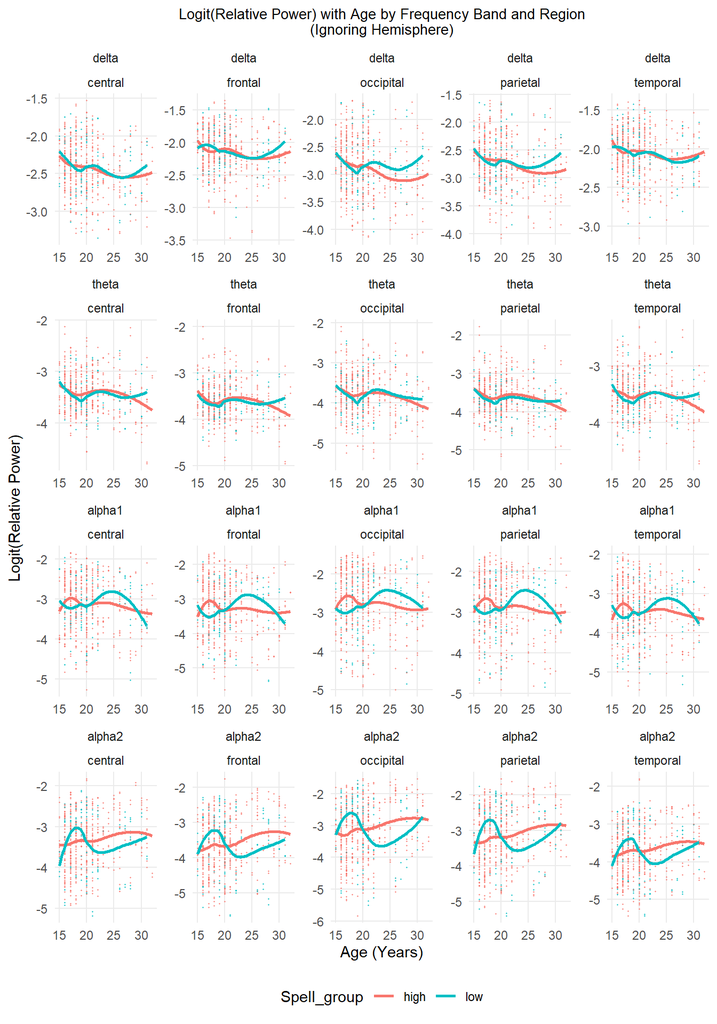